# Disentangling the drivers of reduced long‐distance seed dispersal by birds in an experimentally fragmented landscape - Uriarte - 2011 - Ecology - Wiley Online Library

## Results

### Effects of landscape configuration on plant and disperser abundance, foraging behavior, and movement

#### Flowering plant abundance

We used data collected in censuses of 13 permanent plots (each 50 × 100 m) from 1998 to 2007 to estimate the density of *Heliconia acuminata* flowering plants in the landscape. There was considerable variation in the average abundance of flowering plants between plots in continuous forest and 1- and 10-ha fragments (for CF, 32.54 ± 32.22 flowering *H. acuminata* plants/plot, mean ± SD, *n* = 6 plots; for 10-ha, 19.79 ± 22.71 flowering plants/plot, *n* = 3 plots; for 1-ha, 8.6 ± 7.87 flowering plants/plot, *n* = 4 plots) but means were not significantly different at α = 0.05. Nevertheless, we used these estimates to draw initial plant abundance in the simulations.

#### Bird movement

To quantify the effects of landscape configuration on bird movement, we developed statistical models that describe perching time between movements, movement length, speed, and direction as a function of disperser position in primary vs. secondary forest and distance to the habitat boundary, and we used model comparison to identify the most parsimonious model. Here we provide results for each of these components of movement.

#### 1. Perch times

Best models included species groups (thrush vs. all other species) and habitat type, indicating a substantial increase in perch time in primary forest habitats relative to secondary growth (primary, 20.4 ± 3.99 s, mean ± SE; secondary, 9.3 ± 1.47 s; when zeroes were excluded, 453 ± 77.34 s vs. 350 ± 23.92 s, respectively), and longer perch times for the thrush, but only when zeroes were included (with zeroes, 20 ± 3.61 s, mean ± SE; without zeroes, 360 ± 23.35 s) relative to other dispersers (with zeroes, 13 ± 4.3 s; without zeroes, 453 ± 59.83 s) (Appendix C: Table C1). To capture these patterns, we fitted zero-inflated negative exponential distributions to the data (Appendix C: Table C1).

#### 2. Movement distance and speed

The best models included only habitat (primary vs. secondary forest) as a predictor of bird movement distance and speed (Appendix C: Tables C2 and C3). Birds flew longer distances in primary forest relative to the surrounding secondary forest matrix. To account for these differences, we fitted separate lognormal distributions for movement distance (originally measured in meters) in each habitat: log(distance) mean = 2.95 (0.13 SD) and log(distance) mean = 2.34 (0.13 SD), respectively. Birds also flew faster in primary forest relative to the surrounding secondary forest matrix (4.4 ± 0.18 m/min, mean ± SE (primary forest) vs. 3.5 ± 0.19 m/min (secondary matrix), although maximum speed tended to be higher in secondary forests. To capture this variation, we fitted separate lognormal distributions for primary and secondary forest data: log(flight speed) mean = 1.01 (0.93 SD) and log(flight speed) mean = 0.54 (1.05 SD), respectively.

#### 3. Movement direction

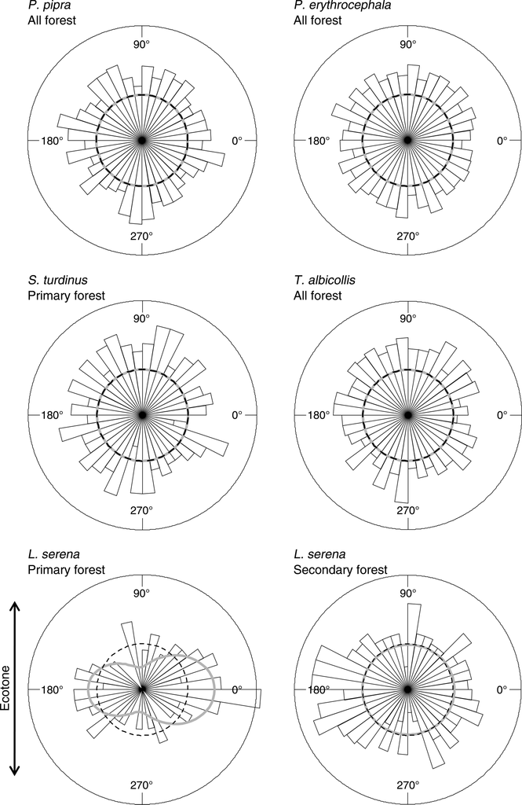

**Figure 1**

Distributions of movement directions (angles, in degrees) of each bird species that disperses *Heliconia acuminata,* an Amazonian understory herb, based on fieldwork in the Biological Dynamics of Forest Fragments Project (BDFFP), near Manaus, Brazil. Data and fitted parameters are shown for the model supported by movement data for each species. *Pipra pipra, P. erythrocephala*, and *Turdus albicollis* did not change movement direction in response to the habitat boundary, so we show data for all forest types together. We only show movement angle data for *Schiffornis turdinus* in primary forest, because this species was restricted to this habitat. *Lepidothrix serena* changed movement direction patterns in response to the habitat boundary between primary and secondary forest. We show the distribution of movement angles in both habitats. Wedges show observed data; dashed black lines show a simple correlated random walk; solid gray lines show the best-fit movement direction model. All directions are relative to a vector parallel to the nearest edge, oriented in the same 180° arc as the previous movement. Parameter estimates and associated support intervals for movement direction models are provided in Appendix D.